# Discover 2015 august: workshopy, týmy, prefekti

*Zpět na rozcestník zpětné vazby*

# Odpolední workshopy

## Hodnocení

Na augustovém turnuse se prolínaly “volné” kariérní workshopy, proto jsou i v hodnocení spolu.

Nejlépe hodnocené workshopy jsou nahoře. Známky jako ve škole.

Průměrná známka (jako ve škole): 1.67

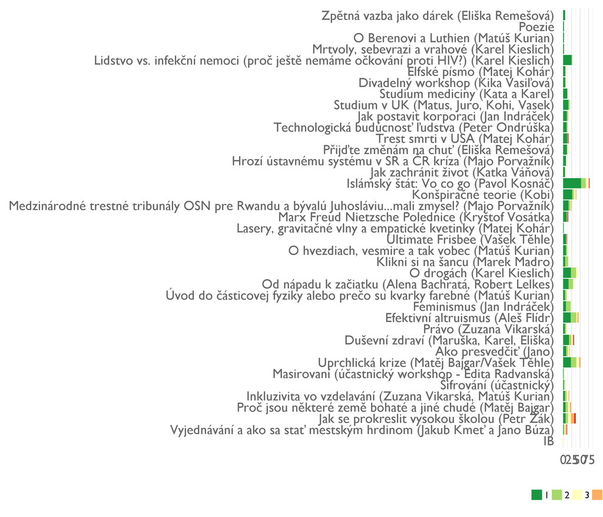

# Týmové workshopy

## Hodnocení

### **Byly týmové workshopy zajímavé?**

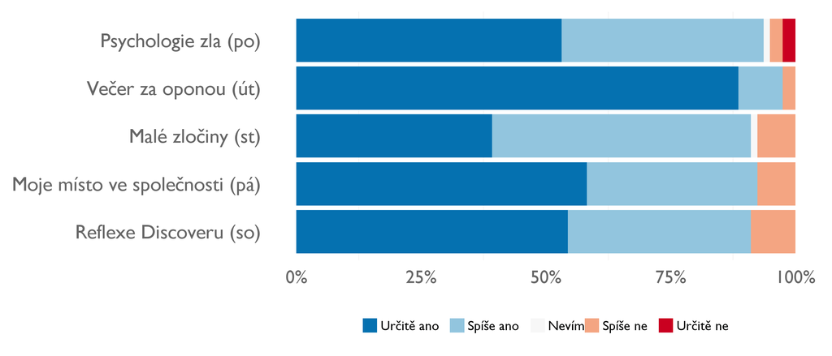

### **Hodnocení týmových workshopů podle předchozí účasti na Discover**

(1 = určitě ano, 5 = určitě ne)

| Předchozí účast | Hodnocení (1=Určitě zajímavé, 5=Určitě nezajímavé) | Počet účastníků |
| --- | --- | --- |
| Na Discover nejméně podruhé | 1.71 | 25 |
| Na Discover poprvé | 1.47 | 54 |
| Celkem | 1.55 | 79 |

### *Komentáře těch, kdo hodnotili spíše pozitivně*

- boli zaujímavé diskusiou v malej skupine kde sme si dobre prezentovali názory
- páčila sa mi spoločná tematika, ktoré sa všetkými niesla. má viesť k royvoju nás ako ľudských bytostí, však? je fajn, že sme sa neroyprávali len o globálnzch veciach a globálnom dobre, ale aj o drobnostiach, ktoré ovplyvňujú kým sme
- NA
- Mali sme možnosť sa viac spoznať a počuť názor iných ľudí.
- Meli jsme skveleho tymoveho ducha a prestoze jsme velmi rozdilni lide, kazdy mohl volne vzjadrit svuj nazor.
- Hodně toho co bylo řečeno v psychologii zla jsem už věděla, večer za oponou mi toho dal hodně, malé zločiny mi nepřišly tolik přínosné, MMVS je myslím velmi důležité téma, takže jsem za workshop opravdu ráda a feedback je důležitá část jakékoliv aktivity.
- Zaujimave boli tym ze kedzy znam mal nejaky nazor a mohli sme sa o tom porozpravt a dojst k nejakemu zaveru
- zdielanie nazorov roznych ludi
- diskusiou a zaujimavostou temy ako takou napr psychologia zla a miesto v spolocnosti boli velmi zaujimave
- Nikdy me nenapadlo nad nekterymi tematy premyslet, bylo zajimave o nich diskutovat v mensi skupine, kde se kazdy mohl zapojit
- Tim, jakych temat se dotykaly, byly zajimave.
- Na normalnych workshopoch nie je cas vsetko prediskutovat, toto bolo na tych skupinovych super, lebo sne sa mohli poriaden porozpravat.
- Určite prístupom, ale aj členmi tímu, ktorí sa nebáli nič povedať.
- Zaujímavé to bolo spoločnou diskusiou a rozímaním nad danou témou.
- Boli zaujimave tym ze sme mohli vecer spolu debatovat o preberanych temach
- Uzasnym timom.
- Celková tymova spolupráca - zaujímavé.
- Byly zajimavé, vždy jsme rozvedli chytlavou debatu do které jsme se všichni zapojili :)
- Boli skvelé tým, že sme sa mohli otvorene porozprávať a vytvoriť si správny názor na mnohé veci
- Dozvedela jsem se fakta, která jsem nečekala a fakta se týkala i me samotné.
- malé skupinky - víc individuální
- podporovali timoveho ducha a boli zaujimave na diskusie
- ako tim sme sa mohli otvorene porozpravat o beznych temach, vypocut si nazor jeden druheho a nasledne nan reagovat. rozobranim tez sme sa jednak naucili viac o danej teme a na druhej strane sme si zdokonalili svoj ustny prejav
- Zaujimave boli tym, ze kazdy mal trochu iny pohlad na danu problematiku a celkova konverzacia.

### *Komentáře těch, kdo hodnotili spíše negativně*

- Byly zajimave, kdyz nastala ruznorodost nazoru, zvlast u veci na ktere jsem mela celkem jasny pohled.
- NA
- Bolo super to ze sme boli v pevnej skupine kde sme mohli robit rozlicne aktivity a diskutovat
- Byly zajímavé díky týmovým diskuzím. Přece jen v týmu je uvolněnější atmosféra a lidé se neostýchají sdílet své myšlenky. Vstřebávání názorů ostatních mi poskytlo větší rozhled.
- Témata. které se tu rozebirali
- No prijde mi, ze ten cas se dal vyuzit efektivneji. Nevim nejsem moc na teamove aktivity… To je spis muj problem, neda se vyhovet vsemu a aj to respektuji.
- Timove workshopy boli zaujimave
- Urcite bylo lepsi ze na diskuze probihali v mensim poctu a tak byl prostor pro to jit vice do hloubky.
- Diskutovali sme viac ako před rokem a viac smě se spoznali
- Opakuju sa ….
- Poznání názoru ostatních lidí.
- utužovalo to vzťahy v tíme
- Diskusie
- V týmu mi bylo dobře, takže jsem se na týmové workshopy vždycky těšila, ale bylo to pro mě spíš o těch lidech než o tom, o čem jsme se bavili. Nenudila jsem se nikde, se vším jsem byla spokojená, ale taky pro mě nic nebylo moc výzvou.
- Kdyz nas vyzivaly a provokovaly k diskusi. Byly velmi zajimave, kdyz nas nutily premyslet o vecech, o kterych jsme driv nepremysleli, o vecech, na ktere neni vzdy jednoznacna odpoved, a to nas vedlo k zajimave diskusi.
- Pomohli mi dotvoriť si obraz o ostatných účastníkoch.
- Boli zaujímvé, iba by som nabudúce zmenila niektoré témy.
- Atmosféra v týmu pro mě nebyla nejlepší, často jsem se cítil přehlížen.
- Boli fajn ale nebavili ma az tak moc lebo som bol asi unaveny z dna
- Diskuze
- Týmovým duchem a take přednesem prefekta a psychologičky :)
- niekedy boli prilis dlhe

## Dopad týmových workshopů

### Změnil se tvůj pohled na některé z témat?

|  | Nezměnil | Změnil | Celkem |
| --- | --- | --- | --- |
| Na Discoveru nejméně podruhé | 4 | 21 | 25 |
| Na Discoveru poprvé | 13 | 41 | 54 |
| Celkem | 17 | 62 | 79 |

### *Proč se pohled změnil:*

- Vzdycky jsem do te doby nevidela vsechny moznosti. Napriklad u teorie zla jsem se musela vyrovnat s tim, ze to tak je, a naucit se proti tomu vedome bojovat. A samozrejme za oponou bylo excelentni protoze clovek vidi, jak jini lide muzou fungovat normalne navzdory hruznym zivotnim zkusenotem.
- dosť ma dorazil worshop o mieste v spoločnosti. vždy som podvedome akosi vedela, že rozdiely sú veľké a že východzie pozície mnohoraké, a predsa sa to ťažko uvedomuje
- Videla som nazory na veci ludi z mojej skupiny okolo mna, co bolo urcite prinosne.
- Psychologia zla ma naucila ze komfortita moze byt casto dost zla a za oponou zasa ze sa treba postavit narocnym situaciam a zvladnut ich
- Myslím si, že som sa stala viac tolerantná a viac načúvať cudzím problémom a názorom
- Určitě malé zločiny a psychologie zla mi pomohli si uvědomit pár věcí v životě.
- Mírně ovlivnil, slyšela sem další argumenty
- psychologické problémy som lepšie pochopila na skutočných ľudoch, viac som sa zamyslela napr nad podvádzaním
- Psychologie zla.
- Spomenula by som Za oponou, ktory jednoznacne zmenil moj pohlad na problemy v mojom osobnom zivote.
- z kazdeho som si nieco uzitocneho zobral.
- Nektera temata mi pred tim nebyla znama.
- Rozhodně Za oponou z důvodů, které jsem zmínila jjiž předtím.
- Hlavne čo sa týka témy Za oponou a moje miesto v spoločnosti.
- Naučil jsem se rozbíjet “trapné ticho” a lidé mě následovali.
- Tema moje miesto v spoločnosti , ako aj psychologia zla mi pomohla uvedomit si dolezite veci v mojom živote, ktore som doteraz nevnimala.
- Ano pohlad na male zlociny je iny za oponou bol inspirativny
- Díky sdílení názorů s ostatními.
- Dusevne zdravie mi zmenil pohlad a za to dakujem
- naučil som sa byt vnímavejsi
- treba viac dbat na ilegalne stahovanie hudby, filmov a pod
- Malé krádeže. Diskusia či je horší okradatrodinualebo kamaRatov
- adoptoval jsem nove nazory a nove pohledy na ruzna temata
- Beriem vic nzoov do uvahy a to pri viacerych workshopoch le napr pri mieste v spolocnosti urcite
- Otvorili oči a stala som sa v mnohých ohľadoch ohľaduplnejšou, otvorenejšou a dúfam že i dlhodobejšie lepším človekom
- Psychologie zla spise ne, vetsinu exerimentu jsem znala, ale neuskodilo si nekere poznatky pripomenot. Ostatni workshopy urcite ano, protoze kazdy z tymu mel trochu jiny pohled na danou vec.
- Asi tim, ze jsem starsi a z jakeho jsem prostredi, jsem o vsech vecech vlastne jiz premyslel a mel jsem na ne nejaky nazor, ktery jsem nejak znacne nezmenil, presto jsem jej casto korigoval. Zaroven bylo skvele videt, jak se formuji nazory mladsich clenu.
- Poté co se všichni vyjádŕili tak jsem mohl reflektovat muj pohled na téma a ten následne upravit.
- Vypocula som si nazory inych a zamyslela som sa nad tym trochu viac…
- počuť názory a pohľady iných u mňa dosť zavážili
- Malé zločiny. Budem sa snažiť vyhýbať sa im.
- Na nektere temata jsme meli diskusi, ktera byla velmi bohata a nase nazory se lisily. To bylo skvele, a muj nazor to mohlo i nejak zmenit. U nekterych temat se mi zdalo, ze jsme se vice mene shodli na nasich nazorech, a pak to nebylo tak prinosne. Ale princip tymovych workshopu se mi libi.
- Hodne jsem se zamyslela nad Psychologii zla a urcite v debate o tomto problemu budu mluvit s lidmi v Praze.
- Pohľad na absolventov top univerzít.
- Nerovnostv spolocnosti, zistil som, ze
- Najma psychológia zla. Ukázala mi ľudské slabosti a prinútila premýšľat nad svojimi činmi.
- Psychologie zla byla velmi přínosná.
- Například malé zločiny o tom ako nezanedbavat.
- Na vsetky temy o kt. sme sa bavili sa zmenil moj pohlad, na danu problematiku k lepsiemu.
- Malé zločiny, moje miesto v spoločnosti.. Diskusia vo mne vyšpecifikovala lepšie názory.
- Když jsme se bavili o rozdílech ve společnosti jsem si začala více uvědomovat že každý to nemá tak jednoduché
- Pretože som sa na nich mohla pozrieť aj z inej stránky :)
- Romske osady a integracia romskych deti do “normalneho sveta”
- Zmenil sa mi pohľad na ludi ktorí maju prostredie ktore nepodporuje vzdelanie
- vacsinou som sa dozvedela zopar novych veci, ktore som o danej tematike predtym nevedela. tieto a aj rozlicne nazory ostatnych clenov mi pomohli lepsie danu tematiku pochopit a viac sa nad nou zamysliet
- Ohledně psychologii zla, že se týká každého z nás.
- male zločiny - sebereflexe
- dozvedela som sa o bystander efekte
- moje misto ve spolecnosti - zmenil nadhled na svet

### *Proč se pohled nezměnil:*

- Stretla som sa na workshopoch s ľuďmi, čo zvačša zdieľali názory podobné mojim. A ak nie, zvačša som si zanechala moje názory, no akceptujem aj iné názory.
- Mam dojem, ze jsme se s tymem hodne shodli.
- Vetsinu veci jsem vedela
- Trvá mi, než si utvořím na něco názor a do té doby jsem všemu (nebo drtivé většině věcí) otevřená. Takže věci, na které jsem pevný názor měla, zůstaly stejné a ty, na které jsem pevný názor neměla byly ovlivněné.
- Väčšinu názorov sme mali rovnakú.
- Nie, ale určite som obhatená o iné názory a dokázala som ich pochopiť.
- Mam svoj nazor a nikdo tam nikoho nepresviedcal iba sme si pivedali co si o danych veciach myslime
- Nevím jestli zmenil názor, spíše jsem se dozvídala nové veci, ale psychologie zla byla pecka!
- Ani velmi nie, lebo som sa neodzvedel nic zasadne prekvapive.

## Máme týmové workshopy změnit? Pokud ano, jak?

|  | Neměnit | Změnit | Celkem |
| --- | --- | --- | --- |
| Na Discoveru nejméně podruhé | 18 | 7 | 25 |
| Na Discoveru poprvé | 44 | 10 | 54 |
| Celkem | 62 | 17 | 79 |

Tedy: častěji by týmové workshopy měnili ti, kdo už Discover zažili.

### *Co změnit:*

- určite by každý rok mali byť trochu iné. sledujem ale pozitívny posun od minulého roku, kedy týmové témy boli trrochu klišé. tie terajšie boli fajn
- Libilo by se mi vice aktivit ve forme her, nebo experimentu, vice nez tymovych debat.
- Mozna by bylo fajn nejake workshopy zmenit, aby to pro cloveka, ktery tu bude podruhe, nebylo porad stejne.
- Možno by som zmenila témy, no neviem na aké.
- Za teamovy workshopberu jen aktivitu s teamem… Za oponou je uplne jina kategorie. Jinak toho opravdu sezeni s teamem bych dala min
- Ako sa vyrovnat s natlakom spolocnosti
- Nebavit se o psychickém zdraví, když jsme všichni rozhozeni přednáškou na citlivé téma
- Psychologia zla som už poznal a nebylo to nic nove
- Robit kazdy rok ine
- Témata by se mohla týkat např. politiky či problémů menšin..
- Různé kulturní rozdíly, které se nám zdají zvláštní nebo špatné?
- Snazila bych se zaradit temata, ktera nas budou provokovat k premysleni a spolecne diskusi a vymene nazoru. Myslim, ze bychom se mohli bavit i o spolecenskych tematech a problemech v nasi spolecnosti, diskutovat o jejich reseni - vysoke skoly, skolne, jejich kvalita nebo jine problemy, ktere prave hybou svetem. Ale hlavne bych se snazila, aby byla temata provokujici k diskusi, v uvozovkach vice kontroverzni.
- Současné problémy našej generacie- závislost na elektronické, cybersikana,…
- jak prezit bez toho ze nebudu na namakani skole
- Mozno ich robit aj nepovinné
- dlzku, niektore boli prilis dlhe

### *Proč nic neměnit:*

- Neměnil bych nic. Forma diskuze po workshopech se mi moc líbila.
- Mně se to vcelku líbila, možná někdy by jsi nerozoberala některé témata tak dlouho
- Tymove workshopy boli zamerane na komplexnejsie temy ako klasicke wokshopy a myslim, ze temy na ne boli vhodne a trefne vybrane.
- nemusite neni to nutne ale mozno mozu byt zahrute aj rozne aktualne temy ako imigranti alebo homosexuali…
- Spoluprace
- Temata podobna, tato byla super uzitecna!
- Bala by som najma témy zo sučastnosti.
- Tato myslienka je super
- s timovymi workshopmi som bola spokojna, mozno by do buducna pridala viac tem rozoberajucich politicku situaciu
- Neviem o nicom protebujucom zmenu.

# Prefekti

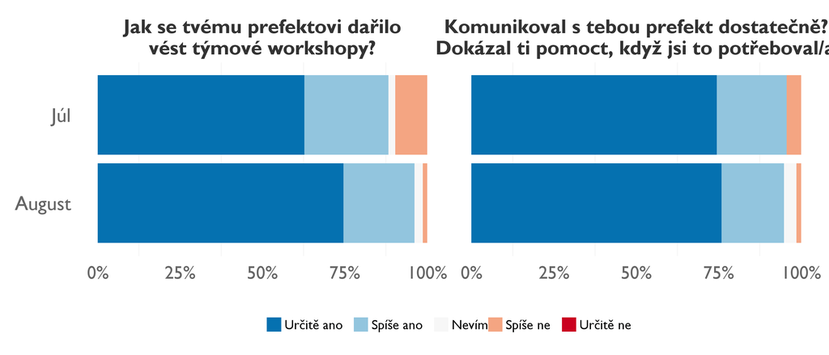

## Komentáře ke komunikaci (jen augustový turnus)

- Prefekt bol uplne super. Bola velmi ochotna kedykolvek sa porozpravat, bola tu pre nas.
- Sice som tuto moznost moc nevyuzival ale lektori nas uistovali ze za nimi mozme kedykolvek prist a opytat sa
- Stejně jako u práva a morálky byl můj prefekt Zuzka, která byla stejně dobrá prefekta jako lektorka a to znamená naprosto úžasná, vždy nám pomohla, měla na nás čas, obětovala pro nás cokoliv a dělala s náma všechno, co jsme měli dělat a poslouchala nás.
- Dominik byl super, choval se k nám moc příjemně.
- Nas prefekt sa k nam po celu dobu spraval ako kamarat, bol vzdy k dispozicii porozpravat sa s nami, vysvetlit nieco a pomoct s niecim. Jednym z najvacsich plusov v ramci Discoveru su pre mna prave nasi prefekti a ich pristup k nam.
- KakaDOM! KakaBEST!
- Dominik byl super prefekt a jsem hrozne vdecna za ten tym, co jsme meli.
- Bol skvelý.
- Kryštof i Bára byli skvělí. Kryštof je supervtipný a když jsme se bavili, cítil jsem, jakobych mluvil s přítelem.
- No… Kohi je fajn, ale myslim, ze jako clovku bych se mu nesla sverit, je zkratka jiny nez ja … A to neni negace
- mal skvely pristup k nam a snazil sa s nami komunikovat o nasich problemoch velka sranda s nim bola a pripadal som si konfortne
- Já jsem pomoc ani nevyhledávala, ale to byla moje volba
- Vsetko bolo tak ako to ma byt
- Pommoc od prefekta jsem nevyhledavala ale v ramci tymovych aktivit byl otevreny a aktivni
- Krásný kobi
- nikdy jsem prefekta nevyhledavala mimo tymovy program
- Matúš je s-u-p-e-r!! A Peťo taky, ale moc s námi nebyl :(
- Muj prefekt byl skvely, velmi otevreny nasim nazorum, vzdy ochotny a nadseny si s nami povidat a diskutovat. projevoval o nas obrovsky zajem.
- V skratke, spoznal som skvelého človeka, môjho rovesníka.
- Prefekt bol najlepší, aký mohol byť. Užila som si to.
- Matúš bl super! Motivátor a zároveň naša veková aj krvná skupina. Lepšie už ani nemohlo byť. Vždy sa snažil a robil onoho viac ako musel.
- Občas bolo náročné nájsř ho
- Neměl jsem tu důvěru, s problémem jsem se raději svěřil někomu jinému.
- Nepytal som sa tak moc ale ked som sa spytal tak bol napomocny
- Som z Hmmm to hovori za vsetko
- Najlepší prefekt, najlepší tým, hmmm? :-D
- Měli jsme ten nejlepší tým. Máme už i vlastní facebook skupinu :D budeme se rozhodně nadále stýkat, protože jsme úžasná skupina lidí
- Áno.. Náš prefekt bol ten najlepší… Hmmmmmm :) ;)
- Matej bol ten najlepši prefekt akého sme si mohli priať :)
- Moji obaja prefekti boli skveli, som velmi rada, ze som mohla byt sucastou ich timu. kedykolvek som nieco potrebovala, vzdy mi boli ochotni poradit a kedykolvek pocas dna sme sa rozpravali, nielen o veciach tykajucich sa kurzov ci organizacie
- Tým byl úžasně poskládaný :)) Hmmm… Byl perfektní a dokázal vždy pomoci, i když jsem na Discover poprvé a i on.

## Komentáře k vedení workshopů (jen augustový turnus)

- Silnejsi opozice k nasim nazorum by byla fajn.
- Lektorka viedla tymove workshopy super kazdy mal moznost sa prejavit a bol zapojeny do diania workshopov
- Pri tymovych debatach jsme se casto dostavali do bodu, kdy jsme se prilis dlouho zastavili u jednoho tematu a debata zacala byt zdlouhava a nudna,
- Jak už jsem napsal, Zuzka nám obětovala všechen svůj čas a byla v tom naprosto fantastická.
- Částečně někdy malý zájem o nás, ale jinak v pohode
- Byl jsem naprosto spokojený.
- Je skvele, ako nas nas prefekt povzbudzoval, aby sme kazdy vyjadrili svoj nazor, ako usmernoval alebo sm sa zapajal do diskusii a pomahala nam najst riesenia.
- Vetsinou jsme se do diskuze dostali sami.
- Vše se vedlo kakadokonale.
- No… Nevim, me to zkratka neprijde uplne prinosne ty teamove diskuze
- Viedol to nenasilnou formou a komunikaovali sme o roznych topics
- Možná být občas asertivnější.
- Bylo to castecne chaoticke ale ok
- -
- Bylo to super, ale mozna bych videl prostor na zlepseni v tom naucit se vest diskuzi do zajimavejsich dimenzi a ne ji jen “korigovat”, aby nespadla kam nema. Ale to je opravdu tezky skill a vyzaduje asi hodne hodne zkusenosti, cili overall super!
- Boli tam dosť chvíle ticha, ktoré nikto nemal záujem vyplniť, ale inak fajn.
- Bol uzasny :)
- Občas by si Matúš mohl víc dupnout, ale to je nic oproti tomu, kolik toho do týmu přinesl a jak suprovej je to člověk.
- Nas prefekt vedl diskusi dobre, podporoval nas vsechny, byl otevreny novym nazorum. Zajimalo ho, co si myslime, vzdy se podelil i o svuj nazor, a byl ochotny ho i zmenit.
- Libilo by se mi vic kdyby vice s nami sdilel svuj vlastni nazor
- Šlo mu to na výbornú.
- nemám čo dodať….
- Ve vedení diskuze bylo vše v pořádku, ale prefekt by se měl více snažit zapojovat všechny členy týmu.
- Karel je super
- náš prefekt byl super, vždy věděl co říct a co udělat když například debata stála nebo jsme nevěděli co dělat
- Nič :)
- Náš prefekt zvládl práci lépe než jsem čekala že by mohl.
- Pacilo sa mi to.
- Snazil sa ich robit zaujimavejsie
- Matej rocks! :)
- Dařilo se mu dobře vést diskuzi a přinést některé myšlenky, když diskuze ustávala.
- Zvladol to vyborne.
- Vytvaral priestor pre kazdeho clena aby sa mohol zapojit do debaty.